# Test for association between ETOH consumption and life expectancy, from 1990 to 2010

**Last edited: December 22, 2015**

**Kellie Ottoboni**

```r
set.seed(38)
library(dplyr)
library(Hmisc)
source("../Code/modeling.R")
library(ModelMatch)
```

## Data cleaning

Data cleaning is identical to the sodium analysis.

# Change over time

The first analysis we do looks at *changes* in these variables from 1990 to 2010. By taking the difference between levels in 2010 and 1990, we control for baseline differences between countries.

```r
countries <- salt2010$country
salt_diff <- salt2010[,-1]-salt1990[,-1]
salt_diff <- cbind(countries, salt_diff)
salt_diff <- filter(salt_diff, !is.na(e0_M))

male <- dplyr::select(salt_diff, e0_M, pc_gdp, Na_M, smoking)
male_etoh <- salt_diff$etohM
colnames(male) <- gsub("_M", "", colnames(male))
female <- dplyr::select(salt_diff, e0_F, Na_F, smoking, pc_gdp)
female_etoh <- salt_diff$etohF
colnames(female) <- gsub("_F", "", colnames(female))
```

## Results

### Unadjusted correlation

We begin by looking at the correlation between the change in alcohol consumption and change in life expectancy at age 30.

```r
unadjusted_corr_M <- permu_pearson(prediction = male$e0, response = 0, treatment = male_etoh, iters = 10000)
unadjusted_corr_F <- permu_pearson(prediction = female$e0, response = 0, treatment = female_etoh, iters = 10000)
```

```
##          Estimate Upper p Lower p Two-sided p
## Male   -0.7518970  1.0000  0.0000      0.0000
## Female -0.5540066  0.9989  0.0011      0.0012
```

### Adjusted for sodium consumption

Next, we predict change in life expectancy using per capita GDP and sodium consumption. We look at the correlation between excess mortality (predicted - actual change in life expectancy) and change in alcohol consumption.

```r
cat('Model selection: male \n')
mod_M_1 <- male %>% select(-smoking) %>% choose_model()
pred_M_1 <- predict(mod_M_1, male)
res_M_1 <- permu_pearson(prediction = pred_M_1, response = male$e0, treatment = male_etoh, iters = 10000)
cat('Model selection: female \n')
mod_F_1 <- female %>% select(-smoking) %>% choose_model()
pred_F_1 <- predict(mod_F_1, female)
res_F_1 <- permu_pearson(prediction = pred_F_1, response = female$e0, treatment = female_etoh, iters = 10000)
```

```
## Model selection: male
##
##            Linear regression        Polynomial regression
##                    2.2245546                    2.2245546
##                         CART                  Bagged CART
##                    1.6396492                    1.4580320
##                Random forest Stochastic gradient boosting
##                    0.6336267                    1.4232234
## Model selection: female
##
##            Linear regression        Polynomial regression
##                    1.0835942                    1.0835942
##                         CART                  Bagged CART
##                    0.6677085                    0.6923382
##                Random forest Stochastic gradient boosting
##                    0.2407614                    0.9866859
```

```
##         Estimate Upper p Lower p Two-sided p
## Male   0.4674098  0.0047  0.9953      0.0061
## Female 0.4079344  0.0122  0.9878      0.0169
```

### Adjusted for sodium consumption and smoking

Finally, we predict change in life expectancy using per capita GDP, Na+ consumption, and annual cigarettes per capita. We look at the correlation between excess mortality (predicted - actual change in life expectancy) and change in alcohol consumption.

```r
cat('Model selection: male \n')
mod_M <- male %>% choose_model()
pred_M <- predict(mod_M, male)
res_M <- permu_pearson(prediction = pred_M, response = male$e0, treatment = male_etoh, iters = 10000)
cat('Model selection: female \n')
mod_F <- female %>% choose_model()
pred_F <- predict(mod_F, female)
res_F <- permu_pearson(prediction = pred_F, response = female$e0, treatment = female_etoh, iters = 10000)
```

```
## Model selection: male
##
##            Linear regression        Polynomial regression
##                    2.0111430                    2.0111430
##                         CART                  Bagged CART
##                    1.6396492                    1.4334043
##                Random forest Stochastic gradient boosting
##                    0.5813418                    1.3610779
## Model selection: female
##
##            Linear regression        Polynomial regression
##                    1.0592760                    1.0592760
##                         CART                  Bagged CART
##                    0.7078903                    0.7323503
##                Random forest Stochastic gradient boosting
##                    0.2447670                    0.9215112
```

```
##         Estimate Upper p Lower p Two-sided p
## Male   0.4697469  0.0041  0.9959      0.0056
## Female 0.3903367  0.0141  0.9859      0.0235
```

## Plots

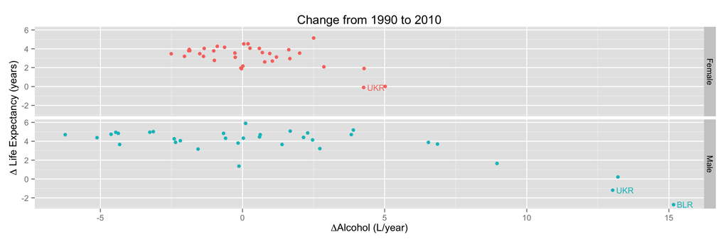

```r
library(ggplot2)

dat <- data.frame("sex"     = c(rep("Male",nrow(male)), rep("Female",nrow(female))),
                  "etoh"  = as.numeric(c(male_etoh, female_etoh)),
                  "le"      = c(male$e0, female$e0),
                  "country" = rep(salt_diff$countries, 2),
                  "ex_mort" = c(pred_M-male$e0, pred_F-female$e0),
                  stringsAsFactors = FALSE)
p1 <- qplot(etoh, le, data = dat, facets = sex~., colour = sex) + theme(legend.position = "none") + labs(x = expression(paste(Delta, "Alcohol (L/year)")), y = expression(paste(Delta, " Life Expectancy (years)")), title = "Change from 1990 to 2010") + geom_text(aes(label=ifelse(le<0,paste(country),"")) , hjust=-0.2, size = 3.5)
p1
```

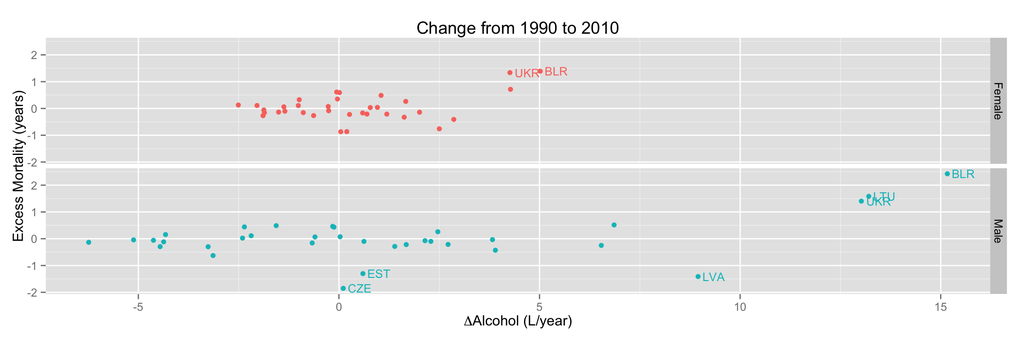

```r
p2 <- qplot(etoh, ex_mort, data = dat, facets = sex~., colour = sex) + theme(legend.position = "none") + labs(x = expression(paste(Delta, "Alcohol (L/year)")), y = "Excess Mortality (years)", title = "Change from 1990 to 2010") + geom_text(aes(label=ifelse(abs(ex_mort) > 1, paste(country), "")), hjust=-0.2, size = 3.5)
p2
```

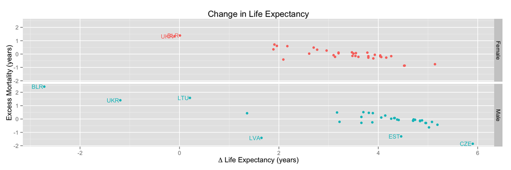

```r
p3 <- qplot(le, ex_mort, data = dat, facets = sex~., colour = sex) + theme(legend.position = "none") + labs(x = expression(paste(Delta, " Life Expectancy (years)")), y = "Excess Mortality (years)", title = "Change in Life Expectancy")  + geom_text(aes(label=ifelse(abs(ex_mort) >1, paste(country), "")), hjust=1.1, size = 3.5)
p3
```

# Absolute associations

The previous analysis accounted for changes in life expectancy and in sodium, alcohol, and tobacco consumption from 1990 to 2010. We also want to look at the correlation between alcohol consumption and life expectancy at a fixed point in time, rather than taking differences.

Aside from the data preparation, the analysis will be the same as the previous section.

```r
salt_imputed <- rbind(salt1990, salt2010)
salt_imputed <- salt_imputed %>% filter(!is.na(e0_M) & !is.na(e0_F))
male <- dplyr::select(salt_imputed, e0_M, Na_M, smoking, pc_gdp)
male_etoh <- salt_imputed$etohM
colnames(male) <- gsub("_?M", "", colnames(male))
female <- dplyr::select(salt_imputed,  e0_F, Na_F, smoking, pc_gdp)
female_etoh <- salt_imputed$etohF
colnames(female) <- gsub("_?F", "", colnames(female))
```

## Results

### Unadjusted correlation

We look at the correlation between alcohol consumption and life expectancy at age 30.

```r
unadjusted_corr_M <- permu_pearson(prediction = male$e0, response = 0, treatment = male_etoh, iters = 10000)
unadjusted_corr_F <- permu_pearson(prediction = female$e0, response = 0, treatment = female_etoh, iters = 10000)
```

```
##           Estimate Upper p Lower p Two-sided p
## Male   -0.36122525  0.9983  0.0017      0.0026
## Female -0.01783668  0.5623  0.4377      0.8826
```

### Adjusted for sodium consumption

Next, we predict life expectancy using sodium consumption and per capita GDP. We look at the correlation between excess mortality (predicted - actual life expectancy) and alcohol consumption.

```r
cat('Model selection: male \n')
mod_M_1 <- male %>% select(-smoking) %>% choose_model()
pred_M_1 <- predict(mod_M_1, male)
res_M_1 <- permu_pearson(prediction = pred_M_1, response = male$e0, treatment = male_etoh, iters = 10000)
cat('Model selection: female \n')
mod_F_1 <- female %>% select(-smoking) %>% choose_model()
pred_F_1 <- predict(mod_F_1, female)
res_F_1 <- permu_pearson(prediction = pred_F_1, response = female$e0, treatment = female_etoh, iters = 10000)
```

```
## Model selection: male
##
##            Linear regression        Polynomial regression
##                     7.049010                     7.049010
##                         CART                  Bagged CART
##                     4.518840                     3.415161
##                Random forest Stochastic gradient boosting
##                     1.141069                     3.378066
## Model selection: female
##
##            Linear regression        Polynomial regression
##                    3.3563843                    3.3563843
##                         CART                  Bagged CART
##                    1.6176078                    1.4513876
##                Random forest Stochastic gradient boosting
##                    0.4913125                    1.6312277
```

```
##          Estimate Upper p Lower p Two-sided p
## Male   0.27795432  0.0101  0.9899      0.0216
## Female 0.09715101  0.2123  0.7877      0.4259
```

### Adjusted for sodium consumption and smoking

Finally, we predict life expectancy using per capita GDP, sodium consumption, and annual cigarettes per capita. We look at the correlation between excess mortality (predicted - actual life expectancy) and alcohol consumption.

```r
cat('Model selection: male \n')
mod_M <- male %>% choose_model()
pred_M <- predict(mod_M, male)
res_M <- permu_pearson(prediction = pred_M, response = male$e0, treatment = male_etoh, iters = 10000)
cat('Model selection: female \n')
mod_F <- female %>% choose_model()
pred_F <- predict(mod_F, female)
res_F <- permu_pearson(prediction = pred_F, response = female$e0, treatment = female_etoh, iters = 10000)
```

```
## Model selection: male
##
##            Linear regression        Polynomial regression
##                    7.0345214                    7.0345214
##                         CART                  Bagged CART
##                    4.5188400                    2.6240004
##                Random forest Stochastic gradient boosting
##                    0.8933685                    1.4409873
## Model selection: female
##
##            Linear regression        Polynomial regression
##                    3.3005427                    3.3005427
##                         CART                  Bagged CART
##                    1.3556126                    1.2966686
##                Random forest Stochastic gradient boosting
##                    0.4340493                    0.9967248
```

```
##        Estimate Upper p Lower p Two-sided p
## Male   0.356758  0.0016  0.9984      0.0026
## Female 0.049294  0.3391  0.6609      0.6790
```

### R and package versions used